# Analiza czynników ryzyka chorób serca

Aleksandra Kocur

2026-03-30

# Wprowadzenie

Celem projektu jest analiza czynników ryzyka chorób serca na podstawie danych medycznych. Badanie koncentruje się na wpływie wieku, cholesterolu, ciśnienia oraz innych zmiennych na występowanie choroby.

# Wczytanie danych

```r
data<-read.csv("heart.csv")

colnames(data)<-c("age", "sex", "cp", "trestbps", "chol", "fbs", "restecg", "thalach", "exang", "oldpeak", "slope", "ca", "thal", "target")
```

cp-ból klatki, trestbps-ciśnienie, chol-cholesterol, fbs-cukier na czczo, restecg-ekg, thalach-max tętno, exang-ból w klatce podczas wysiłku, oldpeak-obniżenie odcinka ST w ekg, slope-nachylenie odcinka ST w ekg, ca-l. zwężonych naczyń krwionośnych, thal-wynik badania przepływu krwi w sercu, target-zdrowy0/chory1

```r
head(data)
```

```
##   age sex cp trestbps chol fbs restecg thalach exang oldpeak slope ca thal
## 1  52   1  0      125  212   0       1     168     0     1.0     2  2    3
## 2  53   1  0      140  203   1       0     155     1     3.1     0  0    3
## 3  70   1  0      145  174   0       1     125     1     2.6     0  0    3
## 4  61   1  0      148  203   0       1     161     0     0.0     2  1    3
## 5  62   0  0      138  294   1       1     106     0     1.9     1  3    2
## 6  58   0  0      100  248   0       0     122     0     1.0     1  0    2
##   target
## 1      0
## 2      0
## 3      0
## 4      0
## 5      0
## 6      1
```

```r
summary(data)
```

```
##       age             sex               cp            trestbps
##  Min.   :29.00   Min.   :0.0000   Min.   :0.0000   Min.   : 94.0
##  1st Qu.:48.00   1st Qu.:0.0000   1st Qu.:0.0000   1st Qu.:120.0
##  Median :56.00   Median :1.0000   Median :1.0000   Median :130.0
##  Mean   :54.43   Mean   :0.6956   Mean   :0.9424   Mean   :131.6
##  3rd Qu.:61.00   3rd Qu.:1.0000   3rd Qu.:2.0000   3rd Qu.:140.0
##  Max.   :77.00   Max.   :1.0000   Max.   :3.0000   Max.   :200.0
##       chol          fbs            restecg          thalach
##  Min.   :126   Min.   :0.0000   Min.   :0.0000   Min.   : 71.0
##  1st Qu.:211   1st Qu.:0.0000   1st Qu.:0.0000   1st Qu.:132.0
##  Median :240   Median :0.0000   Median :1.0000   Median :152.0
##  Mean   :246   Mean   :0.1493   Mean   :0.5298   Mean   :149.1
##  3rd Qu.:275   3rd Qu.:0.0000   3rd Qu.:1.0000   3rd Qu.:166.0
##  Max.   :564   Max.   :1.0000   Max.   :2.0000   Max.   :202.0
##      exang           oldpeak          slope             ca
##  Min.   :0.0000   Min.   :0.000   Min.   :0.000   Min.   :0.0000
##  1st Qu.:0.0000   1st Qu.:0.000   1st Qu.:1.000   1st Qu.:0.0000
##  Median :0.0000   Median :0.800   Median :1.000   Median :0.0000
##  Mean   :0.3366   Mean   :1.072   Mean   :1.385   Mean   :0.7541
##  3rd Qu.:1.0000   3rd Qu.:1.800   3rd Qu.:2.000   3rd Qu.:1.0000
##  Max.   :1.0000   Max.   :6.200   Max.   :2.000   Max.   :4.0000
##       thal           target
##  Min.   :0.000   Min.   :0.0000
##  1st Qu.:2.000   1st Qu.:0.0000
##  Median :2.000   Median :1.0000
##  Mean   :2.324   Mean   :0.5132
##  3rd Qu.:3.000   3rd Qu.:1.0000
##  Max.   :3.000   Max.   :1.0000
```

```r
data$target<-ifelse(data$target>0, 1, 0)
data$sex<-ifelse(data$sex>0, "M", "K")
head(data)
```

```
##   age sex cp trestbps chol fbs restecg thalach exang oldpeak slope ca thal
## 1  52   M  0      125  212   0       1     168     0     1.0     2  2    3
## 2  53   M  0      140  203   1       0     155     1     3.1     0  0    3
## 3  70   M  0      145  174   0       1     125     1     2.6     0  0    3
## 4  61   M  0      148  203   0       1     161     0     0.0     2  1    3
## 5  62   K  0      138  294   1       1     106     0     1.9     1  3    2
## 6  58   K  0      100  248   0       0     122     0     1.0     1  0    2
##   target
## 1      0
## 2      0
## 3      0
## 4      0
## 5      0
## 6      1
```

```r
summary(data)
```

```
##       age            sex                  cp            trestbps
##  Min.   :29.00   Length:1025        Min.   :0.0000   Min.   : 94.0
##  1st Qu.:48.00   Class :character   1st Qu.:0.0000   1st Qu.:120.0
##  Median :56.00   Mode  :character   Median :1.0000   Median :130.0
##  Mean   :54.43                      Mean   :0.9424   Mean   :131.6
##  3rd Qu.:61.00                      3rd Qu.:2.0000   3rd Qu.:140.0
##  Max.   :77.00                      Max.   :3.0000   Max.   :200.0
##       chol          fbs            restecg          thalach
##  Min.   :126   Min.   :0.0000   Min.   :0.0000   Min.   : 71.0
##  1st Qu.:211   1st Qu.:0.0000   1st Qu.:0.0000   1st Qu.:132.0
##  Median :240   Median :0.0000   Median :1.0000   Median :152.0
##  Mean   :246   Mean   :0.1493   Mean   :0.5298   Mean   :149.1
##  3rd Qu.:275   3rd Qu.:0.0000   3rd Qu.:1.0000   3rd Qu.:166.0
##  Max.   :564   Max.   :1.0000   Max.   :2.0000   Max.   :202.0
##      exang           oldpeak          slope             ca
##  Min.   :0.0000   Min.   :0.000   Min.   :0.000   Min.   :0.0000
##  1st Qu.:0.0000   1st Qu.:0.000   1st Qu.:1.000   1st Qu.:0.0000
##  Median :0.0000   Median :0.800   Median :1.000   Median :0.0000
##  Mean   :0.3366   Mean   :1.072   Mean   :1.385   Mean   :0.7541
##  3rd Qu.:1.0000   3rd Qu.:1.800   3rd Qu.:2.000   3rd Qu.:1.0000
##  Max.   :1.0000   Max.   :6.200   Max.   :2.000   Max.   :4.0000
##       thal           target
##  Min.   :0.000   Min.   :0.0000
##  1st Qu.:2.000   1st Qu.:0.0000
##  Median :2.000   Median :1.0000
##  Mean   :2.324   Mean   :0.5132
##  3rd Qu.:3.000   3rd Qu.:1.0000
##  Max.   :3.000   Max.   :1.0000
```

# Analiza

```r
library(ggplot2)
library(dplyr)
table(data$target)
```

```
##
##   0   1
## 499 526
```

```r
prop.table(table(data$target))
```

```
##
##         0         1
## 0.4868293 0.5131707
```

Około 51% badanych ma chorobę serca.

## Wiek a choroba

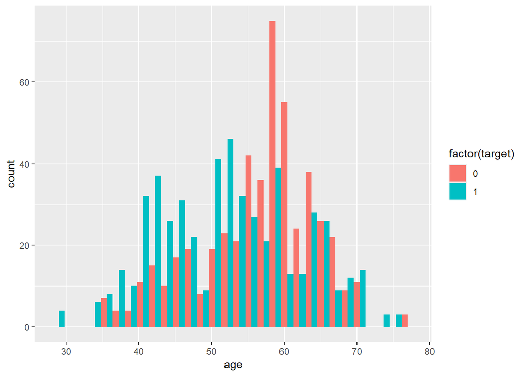

```r
ggplot(data, aes(age, fill=factor(target)))+geom_histogram(position="dodge")
```

Z wykresu wynika, że młodzi częściej chorują, jednak ze względu na różną liczebność grup konieczna jest analiza proporcji.

```r
data$age_group<-cut(data$age, breaks=c(30,40,50,60,70))
table(data$age_group, data$target)
```

```
##
##             0   1
##   (30,40]  23  41
##   (40,50]  81 166
##   (50,60] 234 204
##   (60,70] 158  94
```

```r
prop.table(table(data$age_group, data$target), margin=1)
```

```
##
##                   0         1
##   (30,40] 0.3593750 0.6406250
##   (40,50] 0.3279352 0.6720648
##   (50,60] 0.5342466 0.4657534
##   (60,70] 0.6269841 0.3730159
```

Uzyskane wyniki są niezgodne z oczekiwaniami klinicznymi, według których ryzyko choroby serca rośnie z wiekiem. Może to sugerować ograniczenia danych lub losowy charakter próby.

## Cholesterol a choroba

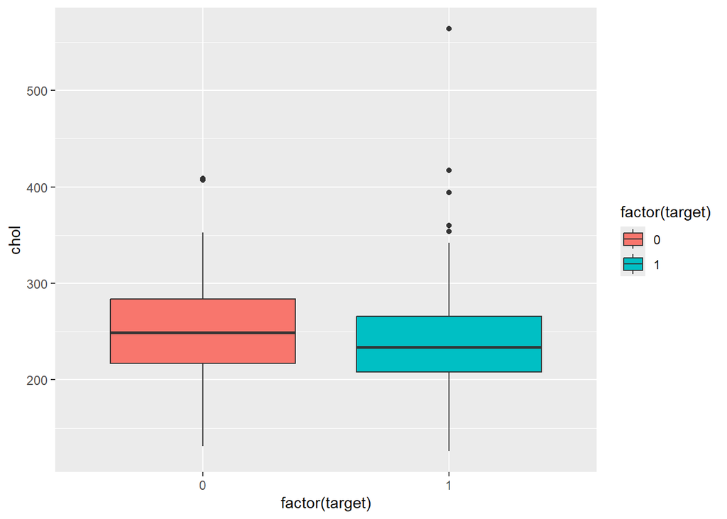

```r
ggplot(data, aes(factor(target), chol, fill=factor(target)))+geom_boxplot()
```

Z wykresu wynika, że poziom cholesterolu nie różni się znacząco miedzy grupą chorych i zdrowych, jednak u grupy zdrowych jego poziom jest minimalnie wyższy. Może to sugerować, że inne czynniki w tej grupie badanych odgrywają ważniejszą rolę.

```r
data%>% group_by(target) %>% summarise(sredni_wiek=mean(age), sredni_chol=mean(chol))
```

```
## # A tibble: 2 × 3
##   target sredni_wiek sredni_chol
##    <dbl>       <dbl>       <dbl>
## 1      0        56.6        251.
## 2      1        52.4        241.
```

```r
t.test(chol~target, data=data)
```

```
##
##  Welch Two Sample t-test
##
## data:  chol by target
## t = 3.2191, df = 1022.8, p-value = 0.001326
## alternative hypothesis: true difference in means between group 0 and group 1 is not equal to 0
## 95 percent confidence interval:
##   4.026703 16.600292
## sample estimates:
## mean in group 0 mean in group 1
##        251.2926        240.9791
```

Mimo, że wizualnie różnice w poziomie cholesterolu nie są duże przeprowadzony test t-Studenta wykazał statystycznie istotną różnicę cholesterolu między grupami. Z analizy wynika, że średni wiek i poziom cholesterolu są wyższe u osób zdrowych.

## Model regresji logistycznej

```r
model<-glm(target~age+chol+trestbps, data=data, family="binomial")
summary(model)
```

```
##
## Call:
## glm(formula = target ~ age + chol + trestbps, family = "binomial",
##     data = data)
##
## Coefficients:
##              Estimate Std. Error z value Pr(>|z|)
## (Intercept)  4.278458   0.614696   6.960 3.40e-12 ***
## age         -0.045879   0.007725  -5.939 2.86e-09 ***
## chol        -0.001935   0.001296  -1.493   0.1354
## trestbps    -0.009477   0.003868  -2.450   0.0143 *
## ---
## Signif. codes:  0 '***' 0.001 '**' 0.01 '*' 0.05 '.' 0.1 ' ' 1
##
## (Dispersion parameter for binomial family taken to be 1)
##
##     Null deviance: 1420.2  on 1024  degrees of freedom
## Residual deviance: 1356.1  on 1021  degrees of freedom
## AIC: 1364.1
##
## Number of Fisher Scoring iterations: 4
```

Zbudowany model regresji logistycznej pokazał, że wiek(p<0.001) oraz ciśnienie tętnicze(p=0.014) mają istotny wpływ na chorobę w badanym zbiorze. Jednak wraz ze wzrostem wieku i ciśnienia maleje prawdopodobieństwo na wystąpienie choroby w badanym zbiorze danych. Poziom cholesterolu okazał się nie istotny statystycznie(p=0.135) w obecności pozostałych zmiennych, co sugeruje, że nie jest on kluczowym czynnikiem wpływającym na chorobę w tej próbie danych.

# Predykcja

```r
nowy1<-data.frame(age=60, chol=250, trestbps=140)
predict(model, nowy1, type="response")
```

```
##         1
## 0.4292494
```

```r
nowy2<-data.frame(age=40, chol=250, trestbps=140)
predict(model, nowy2, type="response")
```

```
##        1
## 0.653095
```

Z modelu wynika, że jest 43% szans, że pacjent “nowy1” jest chory, i 65% szans, że pacjent “nowy2” jest chory.

# Wnioski

Analiza wykazała, że zarówno wiek, poziom cholesterolu, i ciśnienie krwi są związane z niższym prawdopodobieństwem chorób serca. Wyniki nie pokrywają się z wiedzą medyczną, według której ww. czynniki zwiększają ryzyko chorób. Pokazuje to specyficzną strukturę danych, że młodzi w szpitalu kardiologicznym są zazwyczaj bardziej chorzy niż starsi na rutynowych badaniach.